# State Apologies

Clara Laursen & Liva Rask

2026-05-25

## Introduction

This project is about official apologies from the Danish state from 1999 to 2025. We work with six apology texts that have been registered as official apologies issued on behalf of the state.

# Research Question

How does the Danish state use official apologies to acknowledge historical failures and assign responsibility in the period from 1999 to 2025?

To investigate this, we use digital text analysis in RStudio. The script reads the PDF files, cleans the text, divides the texts into words, and creates different analyses and visualizations. We look at word count, sentiment, themes, apology-related word and pronouns and actor groups. The script is part of the final project and is organized so the analysis can be reproduced.

# Setup

```r
library(tidyverse)
library(pdftools)
library(tidytext)
library(stringr)

dir.create("output", showWarnings = FALSE)
```

# Corpus Metadata

```r
metadata <- tribble(
  ~id, ~year, ~author, ~text_type, ~case, ~text_label, ~source_file,

  "pnr_1999", 1999, "Poul Nyrup Rasmussen", "joint declaration", "Thule/Inughuit", "Thule/Inughuit declaration 1999", "pnr_1999.pdf",

  "mindelunden_2005", 2005, "Anders Fogh Rasmussen", "memorial speech", "Occupation/refugees", "Occupation/refugees speech 2005", "mindelunden_2005.pdf",

  "godhavn_2019", 2019, "Mette Frederiksen", "apology speech", "Godhavn Boys", "Godhavn Boys speech 2019", "godhavn_2019.pdf",

  "greenlandic_children_letter_2020", 2020, "Mette Frederiksen", "letter", "Greenlandic children 1951", "Greenlandic children letter 2020", "letter_greenlandic_children_2020.pdf",

  "greenlandic_children_speech_2022", 2022, "Mette Frederiksen", "apology speech", "Greenlandic children 1951", "Greenlandic children speech 2022", "speech_greenlandic_children_2022.pdf",

  "spiral_case_2025", 2025, "Mette Frederiksen", "apology speech", "Spiral case", "Spiral case speech 2025", "spiral_case_2025.pdf"
)

metadata
```

```
## # A tibble: 6 × 7
##   id                          year author text_type case  text_label source_file
##   <chr>                      <dbl> <chr>  <chr>     <chr> <chr>      <chr>
## 1 pnr_1999                    1999 Poul … joint de… Thul… Thule/Inu… pnr_1999.p…
## 2 mindelunden_2005            2005 Ander… memorial… Occu… Occupatio… mindelunde…
## 3 godhavn_2019                2019 Mette… apology … Godh… Godhavn B… godhavn_20…
## 4 greenlandic_children_lett…  2020 Mette… letter    Gree… Greenland… letter_gre…
## 5 greenlandic_children_spee…  2022 Mette… apology … Gree… Greenland… speech_gre…
## 6 spiral_case_2025            2025 Mette… apology … Spir… Spiral ca… spiral_cas…
```

# Text Extraction and Cleaning

```r
speeches_clean <- metadata %>%
  mutate(
    file_path = paste0("data/raw/", source_file),
    text = map_chr(file_path, ~ paste(pdf_text(.x), collapse = " ")),
    text_clean = text %>%
      str_replace_all("\n", " ") %>%
      str_replace_all("\\s+", " ") %>%
      str_to_lower(),

    text_clean = if_else(
      id == "mindelunden_2005",
      str_replace(
        text_clean,
        ".*?deres majestæt, mine damer og herrer",
        "deres majestæt, mine damer og herrer"
      ),
      text_clean
    )
  )
```

# Tokenization

The cleaned texts were divided into individual words.

```r
tokens <- speeches_clean %>%
  select(id, year, author, text_type, case, text_label, text_clean) %>%
  unnest_tokens(word, text_clean)

tokens %>%
  count(text_label, sort = TRUE)
```

```
## # A tibble: 6 × 2
##   text_label                           n
##   <chr>                            <int>
## 1 Godhavn Boys speech 2019          1313
## 2 Occupation/refugees speech 2005   1281
## 3 Spiral case speech 2025            795
## 4 Greenlandic children speech 2022   539
## 5 Thule/Inughuit declaration 1999    360
## 6 Greenlandic children letter 2020   287
```

# Word Count by Text

Before comparing sentiment counts, it is useful to examine the length of each text. Longer texts may naturally contain more sentiment words.

```r
word_counts <- tokens %>%
  count(id, year, text_label, name = "total_words")

word_counts
```

```
## # A tibble: 6 × 4
##   id                                year text_label                  total_words
##   <chr>                            <dbl> <chr>                             <int>
## 1 godhavn_2019                      2019 Godhavn Boys speech 2019           1313
## 2 greenlandic_children_letter_2020  2020 Greenlandic children lette…         287
## 3 greenlandic_children_speech_2022  2022 Greenlandic children speec…         539
## 4 mindelunden_2005                  2005 Occupation/refugees speech…        1281
## 5 pnr_1999                          1999 Thule/Inughuit declaration…         360
## 6 spiral_case_2025                  2025 Spiral case speech 2025             795
```

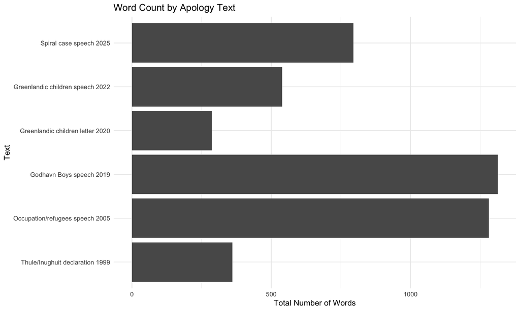

```r
word_count_plot <- ggplot(word_counts, aes(x = reorder(text_label, year), y = total_words)) +
  geom_col() +
  coord_flip() +
  labs(
    title = "Word Count by Apology Text",
    x = "Text",
    y = "Total Number of Words"
  ) +
  theme_minimal()

word_count_plot
```

```r
ggsave(
  "output/word_count_by_text.png",
  word_count_plot,
  width = 10,
  height = 6
)
```

# Danish Sentiment Dictionary

This project uses the Danish AFINN sentiment dictionary. AFINN assigns each word a numerical sentiment score. Positive words have scores above zero, while negative words have scores below zero.

```r
sentiment_dict <- read_tsv(
  "data/sentiment/AFINN-da-32.txt",
  col_names = c("word", "score")
) %>%
  mutate(
    sentiment = case_when(
      score > 0 ~ "positive",
      score < 0 ~ "negative",
      TRUE ~ "neutral"
    )
  )
head(sentiment_dict)
```

```
## # A tibble: 6 × 3
##   word        score sentiment
##   <chr>       <dbl> <chr>
## 1 absorberet      1 positive
## 2 acceptere       1 positive
## 3 accepterede     1 positive
## 4 accepterer      1 positive
## 5 accepteres      1 positive
## 6 accepteret      1 positive
```

# Sentiment Analysis

The tokenized texts are joined with the Danish AFINN dictionary.

```r
sentiment_tokens <- tokens %>%
  inner_join(sentiment_dict, by = "word")

sentiment_counts <- sentiment_tokens %>%
  count(id, year, text_label, sentiment)

sentiment_counts
```

```
## # A tibble: 12 × 5
##    id                                year text_label             sentiment     n
##    <chr>                            <dbl> <chr>                  <chr>     <int>
##  1 godhavn_2019                      2019 Godhavn Boys speech 2… negative     40
##  2 godhavn_2019                      2019 Godhavn Boys speech 2… positive     43
##  3 greenlandic_children_letter_2020  2020 Greenlandic children … negative     10
##  4 greenlandic_children_letter_2020  2020 Greenlandic children … positive      8
##  5 greenlandic_children_speech_2022  2022 Greenlandic children … negative     19
##  6 greenlandic_children_speech_2022  2022 Greenlandic children … positive     13
##  7 mindelunden_2005                  2005 Occupation/refugees s… negative     53
##  8 mindelunden_2005                  2005 Occupation/refugees s… positive     34
##  9 pnr_1999                          1999 Thule/Inughuit declar… negative      5
## 10 pnr_1999                          1999 Thule/Inughuit declar… positive     20
## 11 spiral_case_2025                  2025 Spiral case speech 20… negative     35
## 12 spiral_case_2025                  2025 Spiral case speech 20… positive     23
```

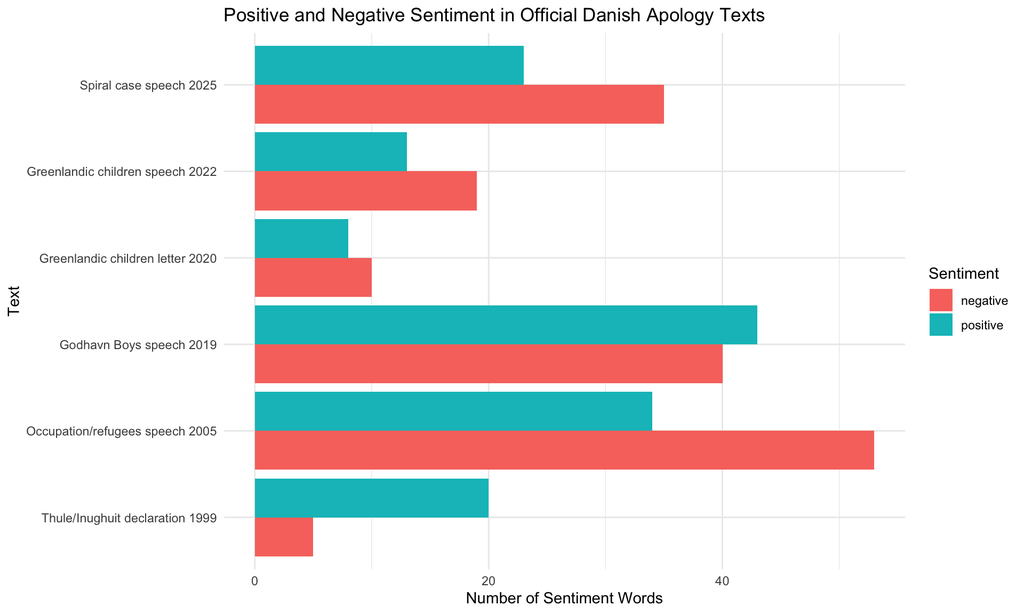

```r
sentiment_plot <- ggplot(sentiment_counts, aes(x = reorder(text_label, year), y = n, fill = sentiment)) +
  geom_col(position = "dodge") +
  coord_flip() +
  labs(
    title = "Positive and Negative Sentiment in Official Danish Apology Texts",
    x = "Text",
    y = "Number of Sentiment Words",
    fill = "Sentiment"
  ) +
  theme_minimal()

sentiment_plot
```

```r
ggsave(
  "output/sentiment_distribution_by_text.png",
  sentiment_plot,
  width = 10,
  height = 6
)
```

# Total Sentiment Score by Text

AFINN assigns each sentiment word a numerical score. This plot shows the total sentiment score for each text. A negative score does not necessarily mean that the apology has a negative function; it may reflect the recognition of harm, suffering and injustice.

```r
sentiment_score <- sentiment_tokens %>%
  group_by(id, year, text_label) %>%
  summarise(total_score = sum(score), .groups = "drop")

sentiment_score
```

```
## # A tibble: 6 × 4
##   id                                year text_label                  total_score
##   <chr>                            <dbl> <chr>                             <dbl>
## 1 godhavn_2019                      2019 Godhavn Boys speech 2019             12
## 2 greenlandic_children_letter_2020  2020 Greenlandic children lette…          -1
## 3 greenlandic_children_speech_2022  2022 Greenlandic children speec…          -5
## 4 mindelunden_2005                  2005 Occupation/refugees speech…         -37
## 5 pnr_1999                          1999 Thule/Inughuit declaration…          26
## 6 spiral_case_2025                  2025 Spiral case speech 2025             -13
```

```r
write_csv(sentiment_score, "output/total_sentiment_score_by_text.csv")
```

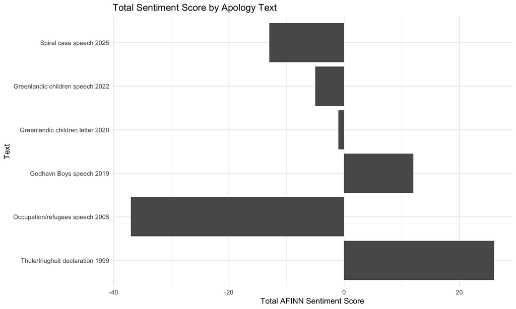

```r
sentiment_score_plot <- ggplot(sentiment_score, aes(x = reorder(text_label, year), y = total_score)) +
  geom_col() +
  coord_flip() +
  labs(
    title = "Total Sentiment Score by Apology Text",
    x = "Text",
    y = "Total AFINN Sentiment Score"
  ) +
  theme_minimal()

sentiment_score_plot
```

```r
ggsave(
  "output/total_sentiment_score_by_text.png",
  sentiment_score_plot,
  width = 10,
  height = 6
)
```

# Thematic Dictionary Analysis

In addition to sentiment analysis, we created a small thematic dictionary to examine words related to responsibility, harm, apology, state actors, reconciliation and the future.

```r
theme_dict <- tribble(
  ~word, ~theme,

  "ansvar", "responsibility",
  "ansvaret", "responsibility",
  "ansvarlig", "responsibility",
  "skyld", "responsibility",
  "svigt", "responsibility",
  "svigtet", "responsibility",
  "fejl", "responsibility",
  "forkert", "responsibility",

  "smerte", "harm",
  "smerten", "harm",
  "overgreb", "harm",
  "uret", "harm",
  "lidelse", "harm",
  "lidelser", "harm",
  "skam", "harm",
  "hjerteløst", "harm",
  "umenneskeligt", "harm",
  "fortræd", "harm",
  "krænket", "harm",

  "undskyld", "apology",
  "undskyldning", "apology",
  "beklage", "apology",
  "beklager", "apology",
  "utoqqatserpugut", "apology",

  "danmark", "state",
  "staten", "state",
  "regeringen", "state",
  "myndigheder", "state",
  "myndighederne", "state",
  "samfundet", "state",
  "rigsfællesskabet", "state",

  "respekt", "reconciliation",
  "anerkendelse", "reconciliation",
  "tillid", "reconciliation",
  "ligeværdighed", "reconciliation",
  "samhørighed", "reconciliation",
  "retfærdighed", "reconciliation",
  "oprejsning", "reconciliation",

  "fremtid", "future",
  "kommende", "future",
  "generationer", "future",
  "ny", "future"
)

theme_counts <- tokens %>%
  inner_join(theme_dict, by = "word") %>%
  count(text_label, year, theme, sort = TRUE)

theme_counts
```

```
## # A tibble: 30 × 4
##    text_label                       year theme              n
##    <chr>                           <dbl> <chr>          <int>
##  1 Godhavn Boys speech 2019         2019 state             12
##  2 Godhavn Boys speech 2019         2019 responsibility    11
##  3 Godhavn Boys speech 2019         2019 apology            8
##  4 Godhavn Boys speech 2019         2019 reconciliation     8
##  5 Occupation/refugees speech 2005  2005 state              8
##  6 Spiral case speech 2025          2025 responsibility     8
##  7 Spiral case speech 2025          2025 apology            7
##  8 Spiral case speech 2025          2025 harm               7
##  9 Spiral case speech 2025          2025 reconciliation     7
## 10 Thule/Inughuit declaration 1999  1999 state              7
## # ℹ 20 more rows
```

```r
write_csv(theme_counts, "output/thematic_dictionary_counts.csv")
```

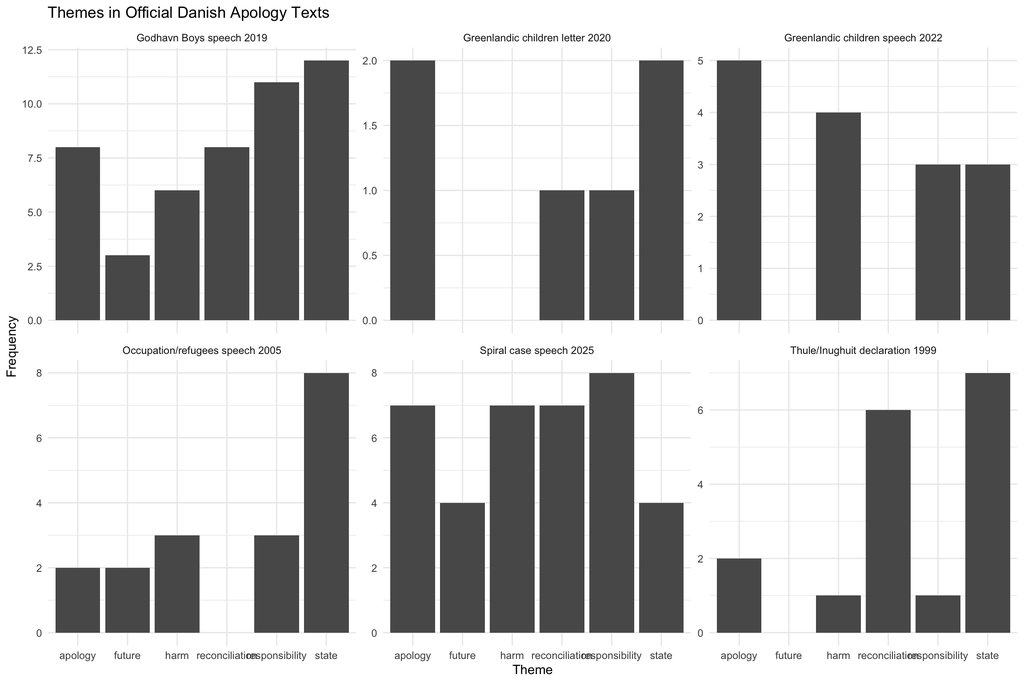

```r
theme_plot <- ggplot(theme_counts, aes(x = theme, y = n)) +
  geom_col() +
  facet_wrap(~ text_label, scales = "free_y") +
  labs(
    title = "Themes in Official Danish Apology Texts",
    x = "Theme",
    y = "Frequency"
  ) +
  theme_minimal()

theme_plot
```

```r
ggsave(
  "output/thematic_dictionary_analysis.png",
  theme_plot,
  width = 12,
  height = 8
)
```

# Apology-related Words

This analysis focuses specifically on words directly related to apology.

```r
apology_words <- c(
  "undskyld",
  "undskyldning",
  "undskyldninger",
  "beklage",
  "beklager",
  "beklagede",
  "utoqqatserpugut"
)

apology_counts <- tokens %>%
  filter(word %in% apology_words) %>%
  count(id, year, text_label, word, sort = TRUE)

apology_counts
```

```
## # A tibble: 11 × 5
##    id                                year text_label                 word      n
##    <chr>                            <dbl> <chr>                      <chr> <int>
##  1 godhavn_2019                      2019 Godhavn Boys speech 2019   unds…     5
##  2 greenlandic_children_speech_2022  2022 Greenlandic children spee… unds…     5
##  3 spiral_case_2025                  2025 Spiral case speech 2025    unds…     5
##  4 godhavn_2019                      2019 Godhavn Boys speech 2019   unds…     3
##  5 spiral_case_2025                  2025 Spiral case speech 2025    unds…     2
##  6 greenlandic_children_letter_2020  2020 Greenlandic children lett… unds…     1
##  7 greenlandic_children_letter_2020  2020 Greenlandic children lett… unds…     1
##  8 mindelunden_2005                  2005 Occupation/refugees speec… bekl…     1
##  9 mindelunden_2005                  2005 Occupation/refugees speec… unds…     1
## 10 pnr_1999                          1999 Thule/Inughuit declaratio… unds…     1
## 11 pnr_1999                          1999 Thule/Inughuit declaratio… utoq…     1
```

```r
write_csv(apology_counts, "output/apology_word_counts.csv")
```

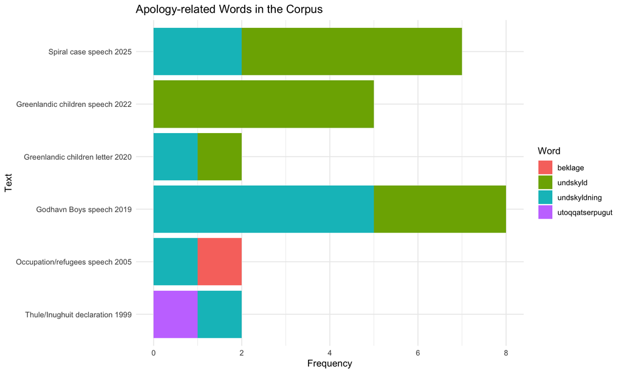

```r
apology_plot <- ggplot(apology_counts, aes(x = reorder(text_label, year), y = n, fill = word)) +
  geom_col(position = "stack") +
  coord_flip() +
  labs(
    title = "Apology-related Words in the Corpus",
    x = "Text",
    y = "Frequency",
    fill = "Word"
  ) +
  theme_minimal()

apology_plot
```

```r
ggsave(
  "output/apology_words_over_time.png",
  apology_plot,
  width = 10,
  height = 6
)
```

# Victim Address and State Actors

This analysis groups pronouns and actors into broader categories: words that address victims directly, words that refer to the speaker, words that refer to collective actors, and words that refer to the state.

```r
actor_groups <- tribble(
  ~word, ~actor_group,

  "du", "victim address",
  "dig", "victim address",
  "jer", "victim address",
  "jeres", "victim address",

  "jeg", "speaker",

  "vi", "collective actor",
  "os", "collective actor",
  "vores", "collective actor",

  "danmark", "state actor",
  "staten", "state actor",
  "regeringen", "state actor",
  "myndigheder", "state actor",
  "myndighederne", "state actor",
  "rigsfællesskabet", "state actor"
)


actor_group_counts <- tokens %>%
  inner_join(actor_groups, by = "word") %>%
  count(text_label, year, actor_group, sort = TRUE)

actor_group_counts
```

```
## # A tibble: 21 × 4
##    text_label                        year actor_group          n
##    <chr>                            <dbl> <chr>            <int>
##  1 Spiral case speech 2025           2025 victim address      35
##  2 Godhavn Boys speech 2019          2019 collective actor    26
##  3 Spiral case speech 2025           2025 collective actor    24
##  4 Godhavn Boys speech 2019          2019 speaker             23
##  5 Godhavn Boys speech 2019          2019 victim address      23
##  6 Greenlandic children speech 2022  2022 victim address      22
##  7 Greenlandic children letter 2020  2020 victim address      16
##  8 Godhavn Boys speech 2019          2019 state actor         11
##  9 Greenlandic children speech 2022  2022 collective actor    10
## 10 Occupation/refugees speech 2005   2005 collective actor    10
## # ℹ 11 more rows
```

```r
write_csv(actor_group_counts, "output/actor_group_counts.csv")
```

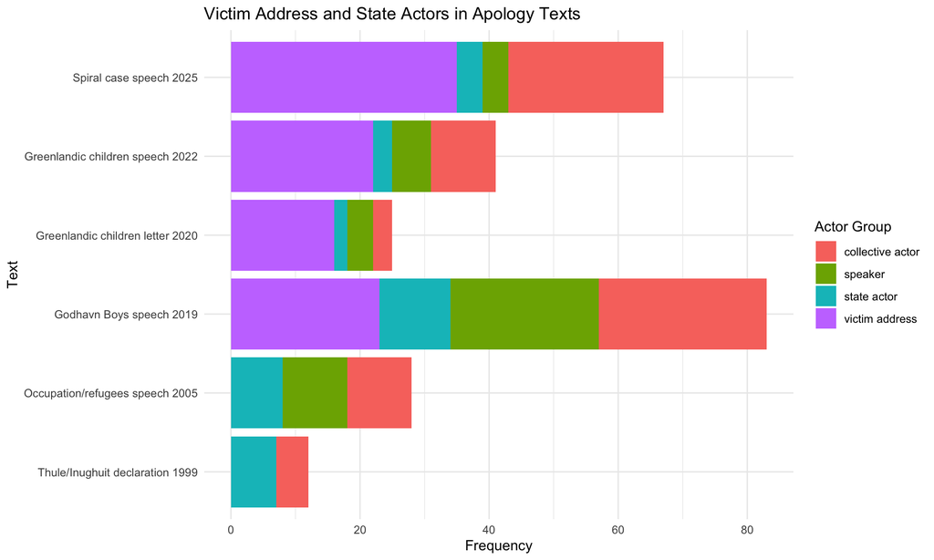

```r
actor_groups_plot <- ggplot(actor_group_counts, aes(x = reorder(text_label, year), y = n, fill = actor_group)) +
  geom_col(position = "stack") +
  coord_flip() +
  labs(
    title = "Victim Address and State Actors in Apology Texts",
    x = "Text",
    y = "Frequency",
    fill = "Actor Group"
  ) +
  theme_minimal()

actor_groups_plot
```

```r
ggsave(
  "output/victim_address_state_actors.png",
  actor_groups_plot,
  width = 10,
  height = 6
)
```